# Homework 2: PCA Image Compression

Johan Gomez

2026-09-24

```r
compress_image <- function(image, k){
  V <- t(image) %*% image
  U <- eigen(V)$vectors
  Z <- image %*% U
  approximation <- matrix(0, nrow = nrow(image), ncol = ncol(image))

  for (i in 1:k) {
    approximation <- approximation + Z[, i] %o% U[, i]
  }
  error <- norm(image - approximation, type = "F")
  return(list(approximation = approximation, error = error))
}
```

# Image 1

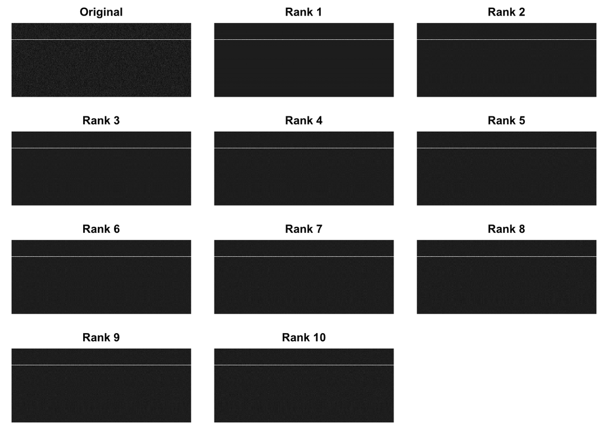

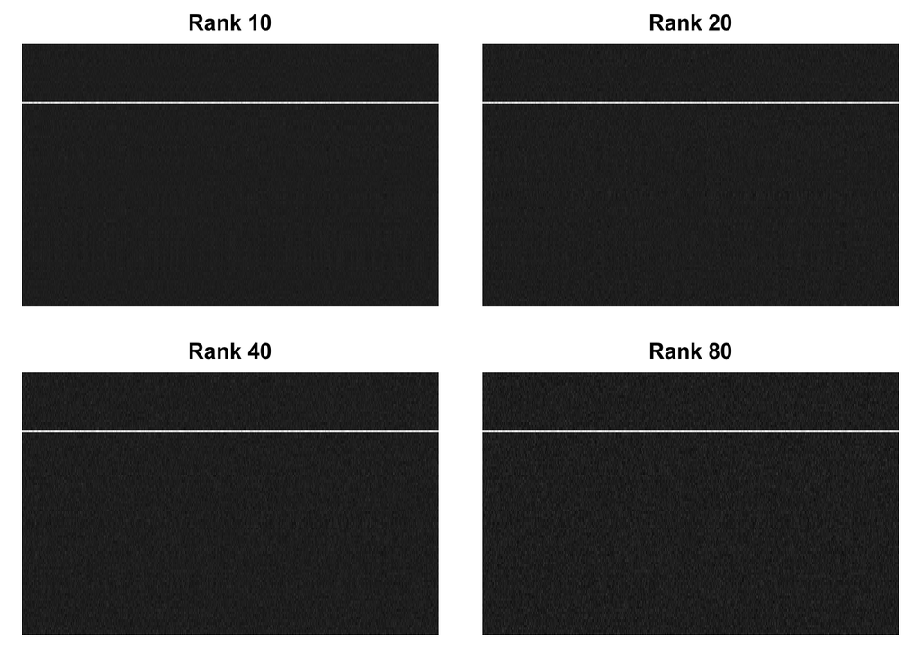

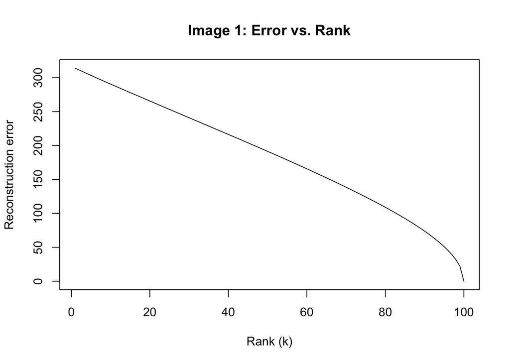

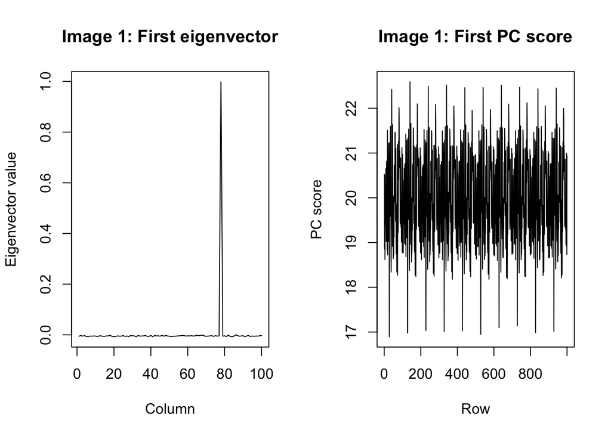

The first eigenvector has a large spike near column 78, corresponding to the prominent line in the image. The first PC score varies across rows, showing how the strength of that pattern changes. The reconstruction error decreases as the rank increases, but preserving the fine texture takes more components than preserving the bright line. I chose rank 40 as an adequate reconstruction. Lower ranks preserve the bright line but smooth away much of the fine texture. By rank 40, enough texture has returned for the image to look reasonably close to the original; rank 80 adds more detail at the cost of using more components.

# Image 2

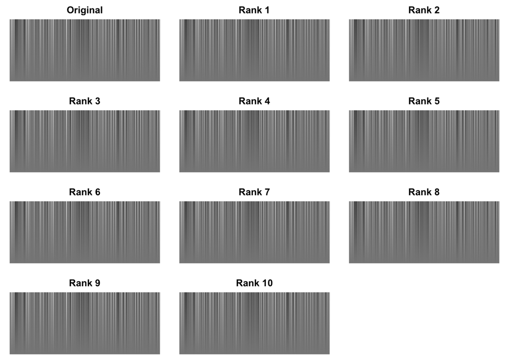

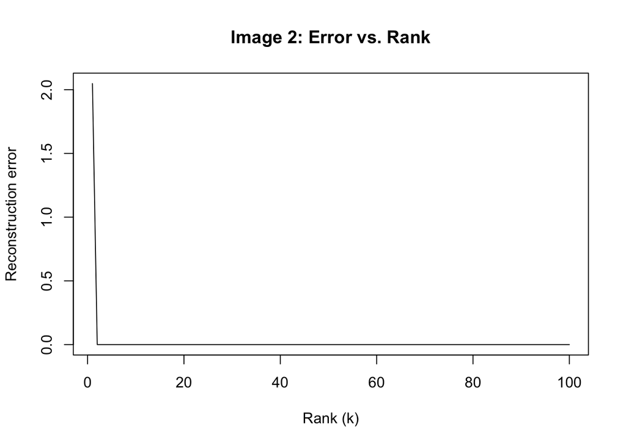

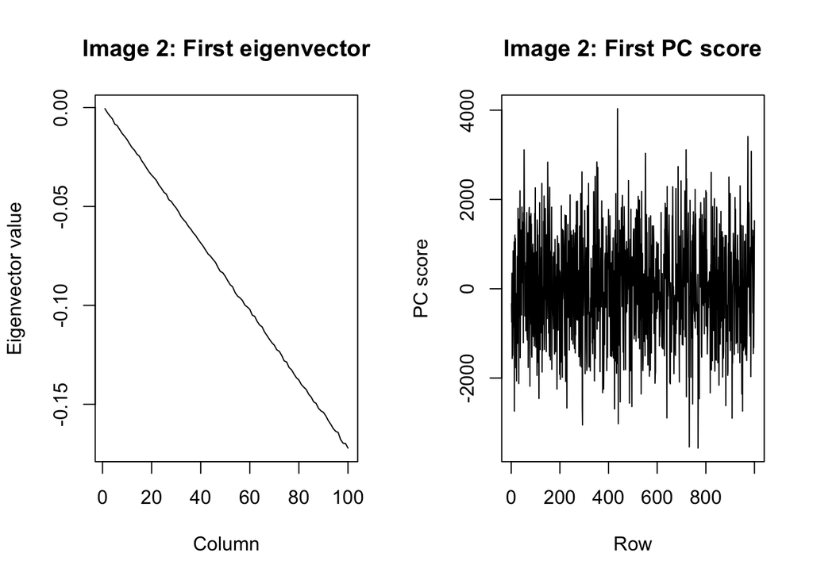

The first eigenvector changes gradually across columns, while the first PC scores vary rapidly across rows. This helps explain the stripe pattern in image 2. I chose rank 2 as adequate because it looks nearly identical to the original and its reconstruction error is effectively zero.

# Image 3

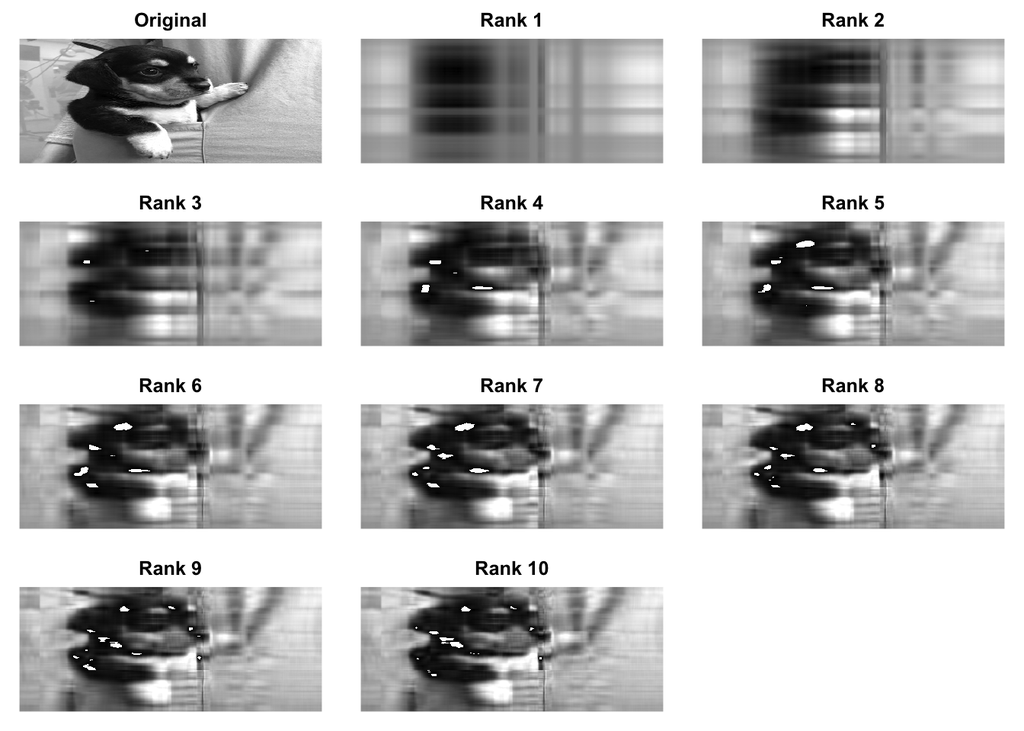

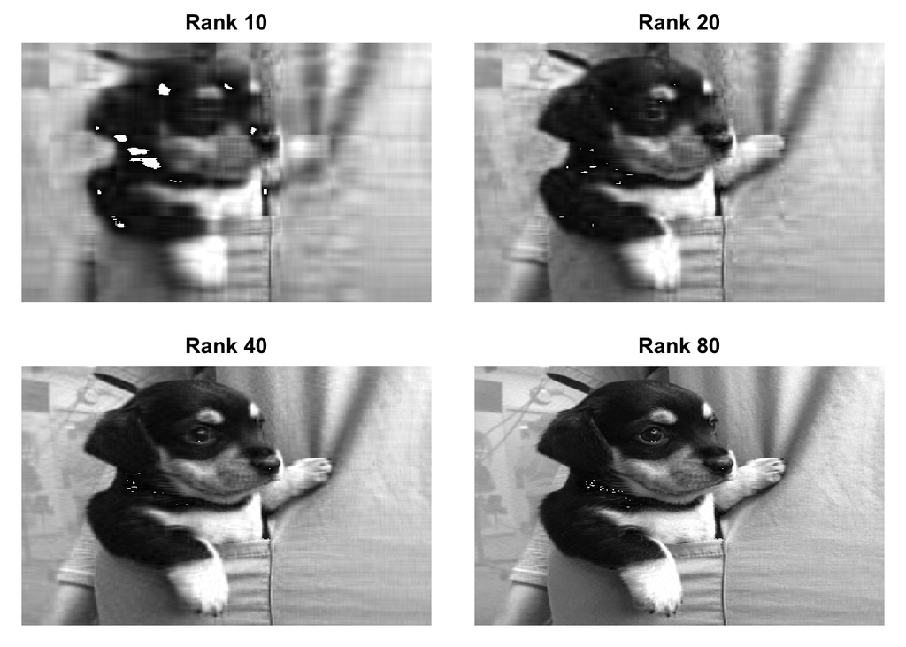

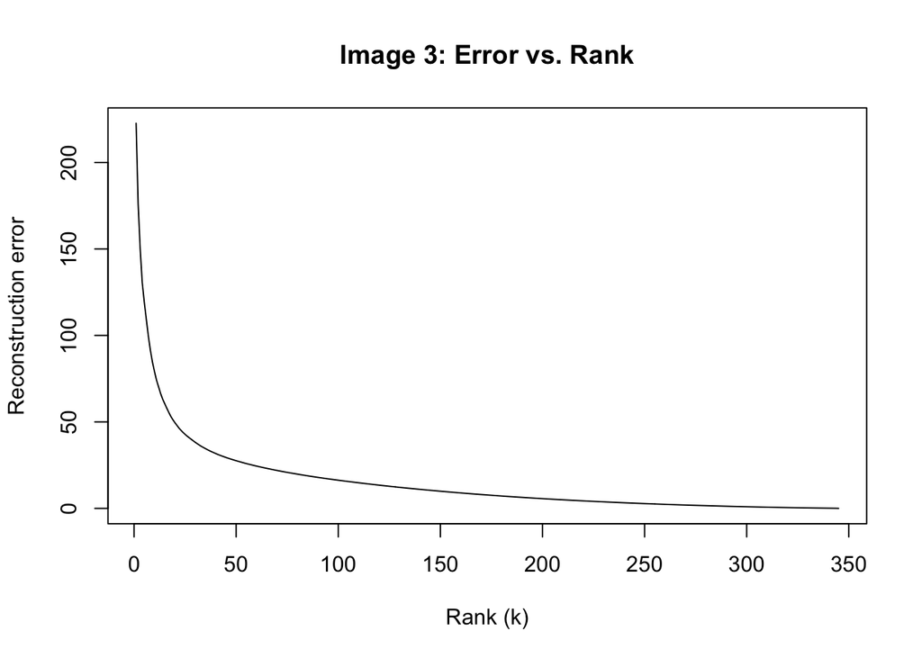

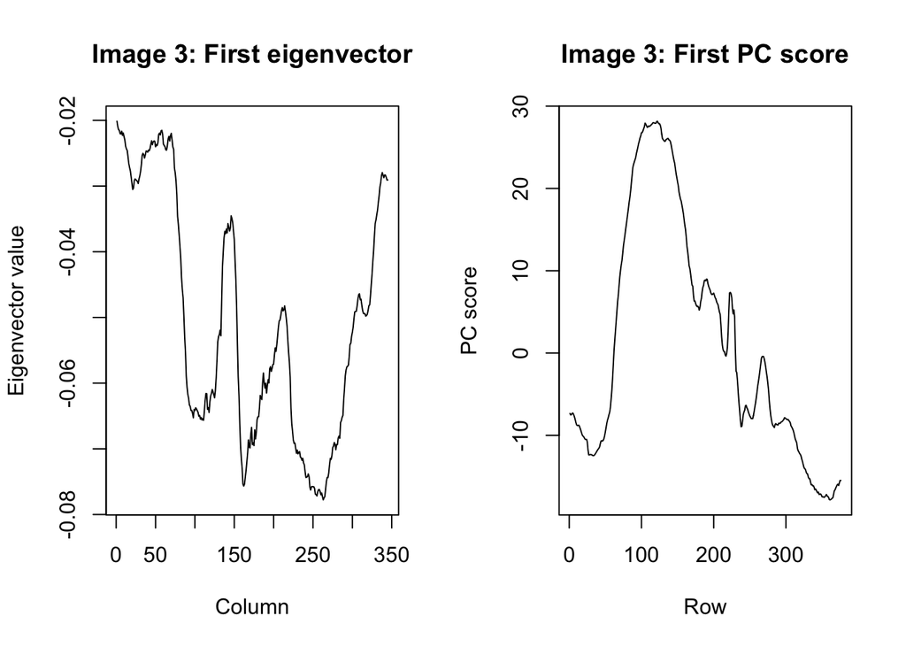

For image 3, the first eigenvector and PC scores vary across the image, reflecting its more complex structure. Reconstruction error decreases quickly at low ranks, but ranks 1–10 leave the dog very blurry. I chose rank 40 as adequate because the dog’s face, paws, and surrounding scene are clear, while it uses only 40 of the 345 possible components.

# Image 4

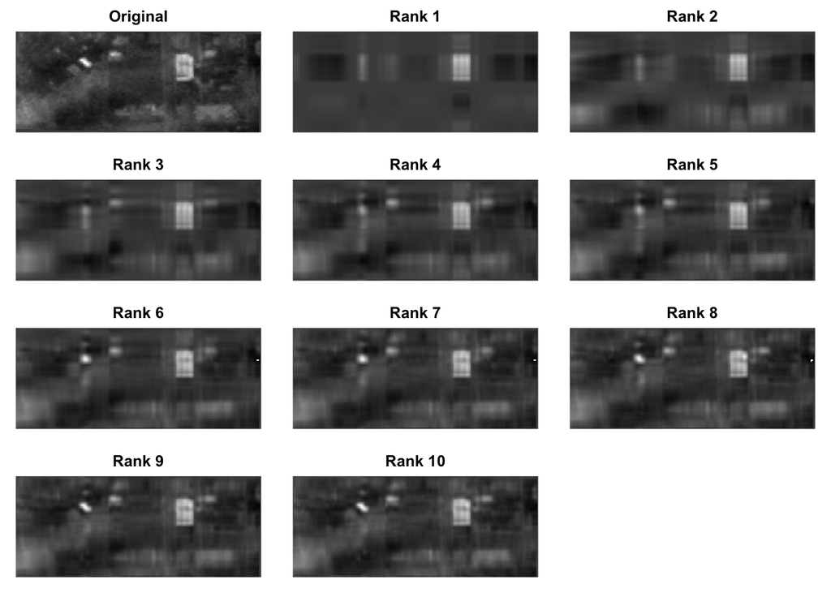

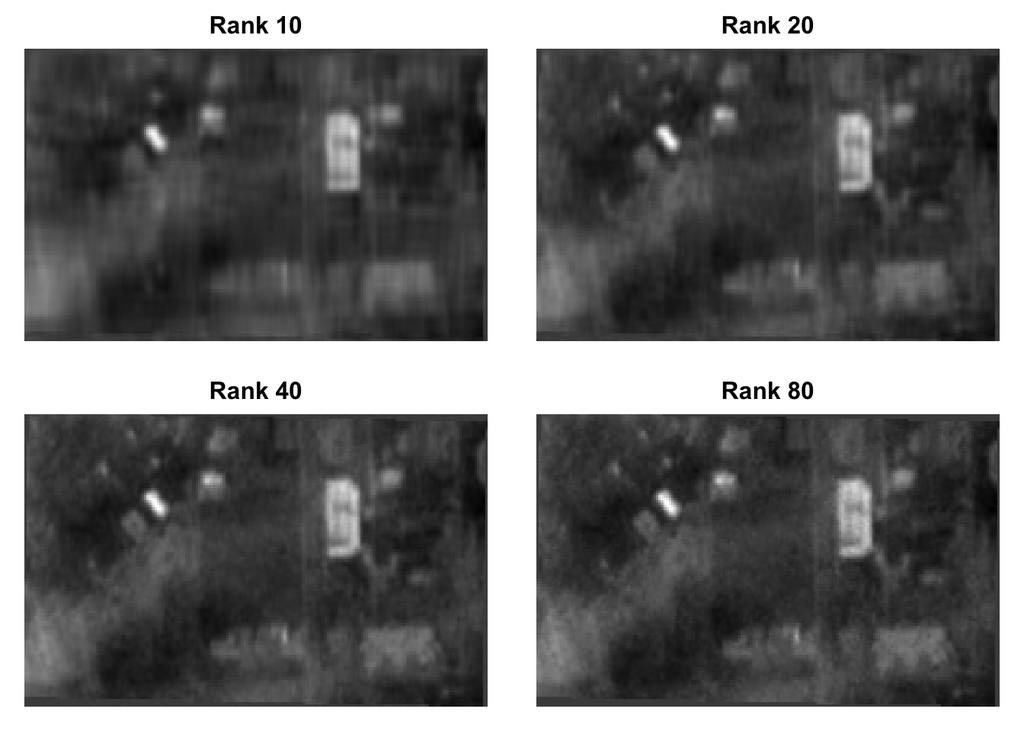

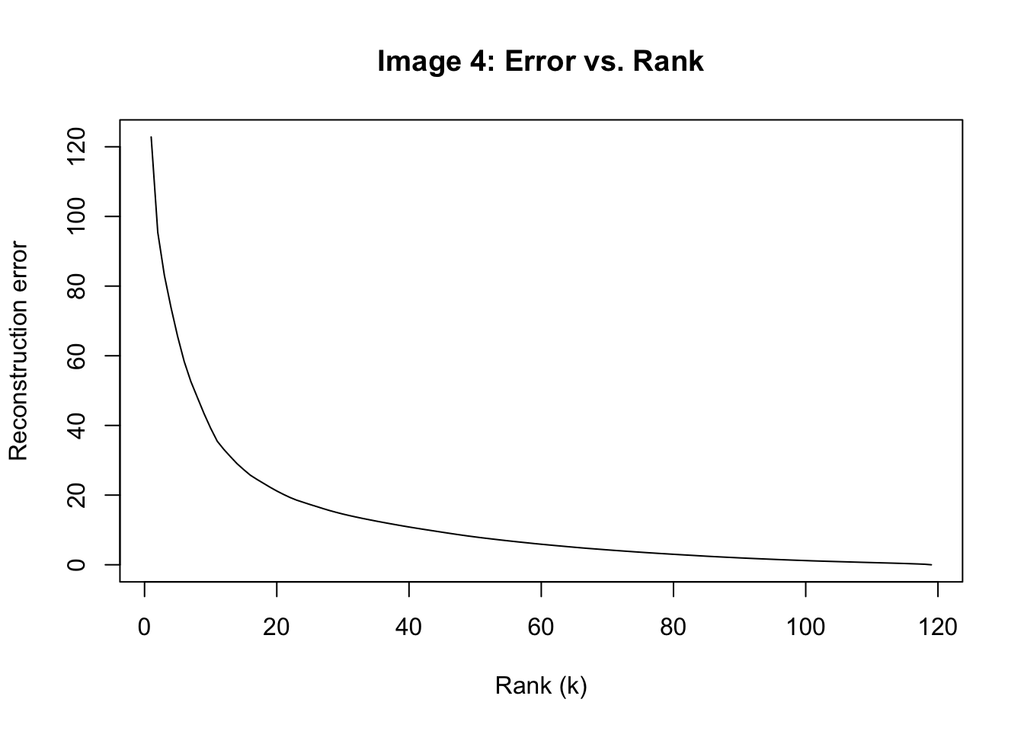

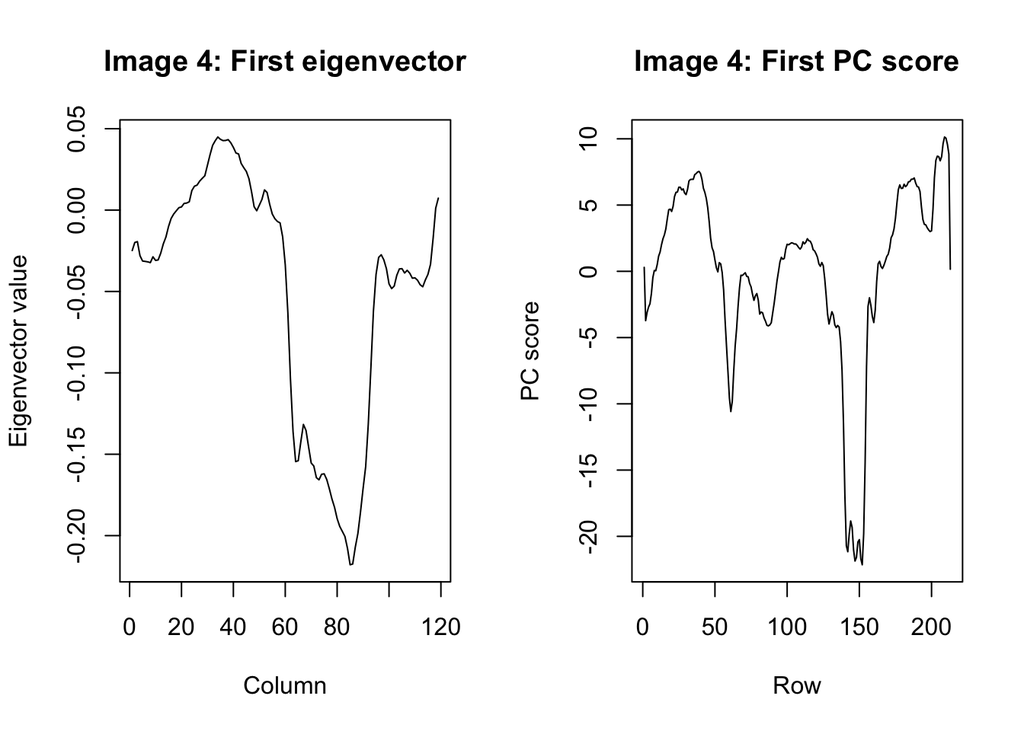

Image 4 is already dark and grainy in the original. Rank 1 captures some broad light and dark areas, while higher ranks recover more detail. I chose rank 20 as an adequate reconstruction because the main features are visible, although it remains blurrier than the original. The reconstruction error drops quickly at low ranks and then decreases more gradually. The first eigenvector varies across columns, and the first PC score varies across rows, showing how the strongest component contributes to different parts of the image.